# A Perspective of Property Value and Police Proximity to Crime Rates at the San Diego Blue Line Trolley

## Dataset #2 Zillow Home Values

This dataset is obtained from Zillow. It provides data about the typical home value across a given region for homes in the 35th to 65th percentile range—the Zillow Home Value Index (ZHVI). The prices date back to 2000-01-31, with the ZHVI being recorded at the end of every month. Some key variables we are interested in from this dataframe include `RegionName`, `RegionType`, `State`, `Metro`, `CountyName`, and dates starting from October 31st, 2021.

```python
home_values_fp = 'zillow_home_values.csv'
zillow_home_values = pd.read_csv(home_values_fp)
zillow_home_values.head()
```

|  | RegionID | SizeRank | RegionName | RegionType | StateName | State | City | Metro | CountyName | 2000-01-31 | ... | 2023-06-30 | 2023-07-31 | 2023-08-31 | 2023-09-30 | 2023-10-31 | 2023-11-30 | 2023-12-31 | 2024-01-31 | 2024-02-29 | 2024-03-31 |
| --- | --- | --- | --- | --- | --- | --- | --- | --- | --- | --- | --- | --- | --- | --- | --- | --- | --- | --- | --- | --- | --- |
| 0 | 112345 | 0 | Maryvale | neighborhood | AZ | AZ | Phoenix | Phoenix-Mesa-Chandler, AZ | Maricopa County | 68055.916438 | ... | 3.226864e+05 | 3.251916e+05 | 3.282309e+05 | 3.309207e+05 | 3.333738e+05 | 3.354533e+05 | 3.370457e+05 | 3.380757e+05 | 3.390568e+05 | 3.405442e+05 |
| 1 | 192689 | 1 | Paradise | neighborhood | NV | NV | Las Vegas | Las Vegas-Henderson-Paradise, NV | Clark County | 135267.765998 | ... | 3.658649e+05 | 3.676967e+05 | 3.706294e+05 | 3.735335e+05 | 3.760529e+05 | 3.782375e+05 | 3.803553e+05 | 3.822835e+05 | 3.841350e+05 | 3.859885e+05 |
| 2 | 270958 | 2 | Upper West Side | neighborhood | NY | NY | New York | New York-Newark-Jersey City, NY-NJ-PA | New York County | 411066.239358 | ... | 1.341331e+06 | 1.334758e+06 | 1.324559e+06 | 1.314097e+06 | 1.302547e+06 | 1.290178e+06 | 1.282332e+06 | 1.276492e+06 | 1.270069e+06 | 1.264422e+06 |
| 3 | 270957 | 3 | Upper East Side | neighborhood | NY | NY | New York | New York-Newark-Jersey City, NY-NJ-PA | New York County | 659533.234940 | ... | 1.294462e+06 | 1.289979e+06 | 1.285379e+06 | 1.280716e+06 | 1.272250e+06 | 1.260767e+06 | 1.250209e+06 | 1.243174e+06 | 1.236986e+06 | 1.232940e+06 |
| 4 | 118208 | 4 | South Los Angeles | neighborhood | CA | CA | Los Angeles | Los Angeles-Long Beach-Anaheim, CA | Los Angeles County | 134786.397244 | ... | 6.582787e+05 | 6.658748e+05 | 6.760560e+05 | 6.863625e+05 | 6.951129e+05 | 7.019075e+05 | 7.063378e+05 | 7.039896e+05 | 6.972987e+05 | 6.903372e+05 |

5 rows × 300 columns

#### 1. How was `sd_home_values` created?

1. Filtered dataset to include only San Diego County properties.
2. Filtered dataset to include prices from one month before `2021-11-30`(the opening of the Blue Line trolley stop at UCSD campus) to the most recent month.
3. Dropped unnecessary columns and converted to csv.

```python
sd_home_values = zillow_home_values[zillow_home_values['CountyName'] == 'San Diego County']

num_cols = len(sd_home_values.columns)
sd_home_values = sd_home_values.iloc[:, list(range(9)) + list(range(num_cols - 30, num_cols))]


cols_drop = ['SizeRank', 'StateName']
sd_home_values = sd_home_values.drop(columns=cols_drop)


sd_home_values.to_csv('cleaned_sd_home_values.csv', index=False)
sd_home_values.head()
```

|  | RegionID | RegionName | RegionType | State | City | Metro | CountyName | 2021-10-31 | 2021-11-30 | 2021-12-31 | ... | 2023-06-30 | 2023-07-31 | 2023-08-31 | 2023-09-30 | 2023-10-31 | 2023-11-30 | 2023-12-31 | 2024-01-31 | 2024-02-29 | 2024-03-31 |
| --- | --- | --- | --- | --- | --- | --- | --- | --- | --- | --- | --- | --- | --- | --- | --- | --- | --- | --- | --- | --- | --- |
| 89 | 116625 | Mira Mesa | neighborhood | CA | San Diego | San Diego-Chula Vista-Carlsbad, CA | San Diego County | 7.909030e+05 | 7.947749e+05 | 8.029774e+05 | ... | 9.108561e+05 | 9.259285e+05 | 9.430418e+05 | 9.603600e+05 | 9.743040e+05 | 9.834509e+05 | 9.901680e+05 | 9.967258e+05 | 1.006417e+06 | 1.019400e+06 |
| 95 | 343228 | Southwest | neighborhood | CA | Chula Vista | San Diego-Chula Vista-Carlsbad, CA | San Diego County | 6.130249e+05 | 6.137920e+05 | 6.171048e+05 | ... | 6.934955e+05 | 7.034853e+05 | 7.139887e+05 | 7.236314e+05 | 7.319901e+05 | 7.382049e+05 | 7.430840e+05 | 7.467625e+05 | 7.509317e+05 | 7.570842e+05 |
| 172 | 343244 | Northwest | neighborhood | CA | Chula Vista | San Diego-Chula Vista-Carlsbad, CA | San Diego County | 6.452574e+05 | 6.464710e+05 | 6.507760e+05 | ... | 7.195701e+05 | 7.287672e+05 | 7.389097e+05 | 7.481860e+05 | 7.563439e+05 | 7.625271e+05 | 7.674295e+05 | 7.712530e+05 | 7.757498e+05 | 7.824709e+05 |
| 182 | 117557 | Rancho Penasquitos | neighborhood | CA | San Diego | San Diego-Chula Vista-Carlsbad, CA | San Diego County | 1.066124e+06 | 1.077560e+06 | 1.095914e+06 | ... | 1.260169e+06 | 1.280856e+06 | 1.303991e+06 | 1.328596e+06 | 1.349857e+06 | 1.364452e+06 | 1.371689e+06 | 1.375539e+06 | 1.385696e+06 | 1.405995e+06 |
| 197 | 273140 | Carmel Valley | neighborhood | CA | San Diego | San Diego-Chula Vista-Carlsbad, CA | San Diego County | 1.475926e+06 | 1.498744e+06 | 1.530745e+06 | ... | 1.767476e+06 | 1.793098e+06 | 1.821107e+06 | 1.846432e+06 | 1.869365e+06 | 1.886040e+06 | 1.895003e+06 | 1.901779e+06 | 1.916004e+06 | 1.945367e+06 |

5 rows × 37 columns

### Using Neighborhoods to Study La Jolla versus Non-La Jolla Trolley Stops

Since we do not have the latitude and longitude of the property values, we can make the most out of our dataset by associating La Jolla Trolley stops with a particular neighbhorhood. One way that was done is outline below:

#### 2. How was the `crimes_and_homes` created?

1. Normalized names for neighborhoods.
2. Merged the dataset `crimes_report` and `sd_home_values`. Then dropping rows with null values.
3. Found the average home values by neighborhood and store this information in the column `avg_home_value`.

```python
crimes_report['neighborhood'] = (crimes_report['neighborhood'].str.upper()
                                 .replace('JAMACHA-LOMITA', 'JOMACHA-LOMITA')
                                 .replace('KEARNEY MESA', 'KEARNY MESA')
                                 .replace('GASLAMP', 'GASLAMP QUARTER')
                                 .replace('TORREY PINES', 'LA JOLLA')
                                 .replace('TIERRA SANTA', 'TIERRASANTA')
                                 .replace('MIRAMAR', 'MIRAMAR RANCH NORTH')
                                 .replace('MISSION BAY PARK', 'BAY PARK')
                                 .replace('BORDER', 'SAN YSIDRO')
                                 .replace('PETCO PARK', 'EAST VILLAGE')
                                 )
sd_home_values['RegionName'] = sd_home_values['RegionName'].str.upper()



crimes_and_homes = crimes_report.merge(sd_home_values, left_on='neighborhood', right_on='RegionName', how='left')
crimes_and_homes = crimes_and_homes.dropna(subset=['RegionName'])


crimes_and_homes['avg_home_value'] = crimes_and_homes.iloc[:, 21:].mean(axis=1)
crimes_and_homes.head()
```

|  | nibrs_uniq | occurred_on | day_of_week | code_section | neighborhood | block_addr | city | state | zip | latitude | ... | 2023-07-31 | 2023-08-31 | 2023-09-30 | 2023-10-31 | 2023-11-30 | 2023-12-31 | 2024-01-31 | 2024-02-29 | 2024-03-31 | avg_home_value |
| --- | --- | --- | --- | --- | --- | --- | --- | --- | --- | --- | --- | --- | --- | --- | --- | --- | --- | --- | --- | --- | --- |
| 0 | 3044145_13A_2 | 2022-11-23 13:43:45 | 4 | 245 (A)(1) PC ASSAULT W/DEADLY WEAPON:NOT F/AR... | EAST VILLAGE | 14th ST & national AVE | SAN DIEGO | CA | 92113.0 | 32.705407 | ... | 6.672742e+05 | 6.704466e+05 | 6.738262e+05 | 6.772098e+05 | 6.798052e+05 | 6.796078e+05 | 6.784956e+05 | 6.778140e+05 | 6.789785e+05 | 6.617293e+05 |
| 1 | 3054619_200 | 2022-12-27 18:44:00 | 3 | 451 (D) PC ARSON:PROP (F) \|\| | CORE-COLUMBIA | 900 10th AVE | SAN DIEGO | CA | 92101.0 | 32.714746 | ... | 1.117251e+06 | 1.124233e+06 | 1.131977e+06 | 1.138689e+06 | 1.143355e+06 | 1.141057e+06 | 1.136655e+06 | 1.133561e+06 | 1.136818e+06 | 1.106129e+06 |
| 2 | 3099629_90Z | 2023-05-23 17:26:00 | 3 | 5150 WI MENTAL DISORDER 72 HR OBSERVATION \|\| | EAST VILLAGE | 1200 Imperial AVE | SAN DIEGO | CA | 92101.0 | 32.706329 | ... | 6.672742e+05 | 6.704466e+05 | 6.738262e+05 | 6.772098e+05 | 6.798052e+05 | 6.796078e+05 | 6.784956e+05 | 6.778140e+05 | 6.789785e+05 | 6.617293e+05 |
| 3 | 3007831_13A_2 | 2022-07-27 10:00:39 | 4 | 245 (A)(4) PC ADW WITH FORCE:POSSIBLE GBI (M) \|\| | EAST VILLAGE | 100 14th ST | SAN DIEGO | CA | 92101.0 | 32.706341 | ... | 6.672742e+05 | 6.704466e+05 | 6.738262e+05 | 6.772098e+05 | 6.798052e+05 | 6.796078e+05 | 6.784956e+05 | 6.778140e+05 | 6.789785e+05 | 6.617293e+05 |
| 4 | 3061756_90E | 2023-01-22 20:55:00 | 1 | 647 (F) PC DRUNK IN PUBLIC: ALCOHOL, DRUGS, CO... | MIDTOWN | 1700 Hancock ST | SAN DIEGO | CA | 92101.0 | 32.741995 | ... | 1.244183e+06 | 1.262817e+06 | 1.283069e+06 | 1.301506e+06 | 1.314964e+06 | 1.319847e+06 | 1.319815e+06 | 1.321694e+06 | 1.330795e+06 | 1.227244e+06 |

5 rows × 52 columns

### Dataset #3 Police Stations

#### 3. How was `sd_police_stations` created?

This dataset was obtained from the summary provided [here](https://sandiego.adl.org/files/2017/03/knowyoursd.pdf), and the CSV was manually generated. It had 30 observations and 8 variables. A preview of the data is shown below.

```python
sd_police_stations = pd.read_csv("sd_police_stations.csv")
sd_police_stations.head()
```

|  | type | name | address | city | state | zipcode | latitude | longitude |
| --- | --- | --- | --- | --- | --- | --- | --- | --- |
| 0 | San Diego Police Department | Northwestern Division | 12592 El Camino Real | San Diego | CA | 92130 | 32.947510 | -117.237892 |
| 1 | San Diego Police Department | Northeastern Division | 13396 Salmon River Rd | San Diego | CA | 92129 | 32.959229 | -117.122940 |
| 2 | San Diego Police Department | Northern Division | 4275 Eastgate Mall | San Diego | CA | 92037 | 32.876793 | -117.215607 |
| 3 | San Diego Police Department | Western Division | 5215 Gaines St | San Diego | CA | 92110 | 32.764118 | -117.194527 |
| 4 | San Diego Police Department | Eastern Division | 9225 Aero Dr | San Diego | CA | 92123 | 32.809448 | -117.129036 |

# Results

## Exploratory Data Analysis

```python
%matplotlib inline

sns.set_theme(context='notebook',
              style='white',
              font_scale=1.5)
```

### Missing Values

1. How can we check missing values for each dataset: `cleaned_sd_crimes_report.csv`, `cleaned_sd_home_values.csv`, and `sd_police_stations.csv`?

```python
crimes_and_homes.isnull().sum()
```

```
nibrs_uniq          0
occurred_on         0
day_of_week         0
code_section        0
neighborhood        0
block_addr        516
city                0
state               0
zip                11
latitude            0
longitude           0
min_distance        0
closest_stop        0
la_jolla            0
RegionID            0
RegionName          0
RegionType          0
State               0
City                0
Metro               0
CountyName          0
2021-10-31          0
2021-11-30          0
2021-12-31          0
2022-01-31          0
2022-02-28          0
2022-03-31          0
2022-04-30          0
2022-05-31          0
2022-06-30          0
2022-07-31          0
2022-08-31          0
2022-09-30          0
2022-10-31          0
2022-11-30          0
2022-12-31          0
2023-01-31          0
2023-02-28          0
2023-03-31          0
2023-04-30          0
2023-05-31          0
2023-06-30          0
2023-07-31          0
2023-08-31          0
2023-09-30          0
2023-10-31          0
2023-11-30          0
2023-12-31          0
2024-01-31          0
2024-02-29          0
2024-03-31          0
avg_home_value      0
dtype: int64
```

```python
sd_police_stations.isnull().sum()
```

```
type         0
name         0
address      0
city         0
state        0
zipcode      0
latitude     0
longitude    0
dtype: int64
```

2. Why are we not going to drop missing values from `crimes_and_homes`? \

As previously, stated, we are interested in merging our datasets with respect to the `neighborhoods` and since the `longitude` and `latitude` columns are are filled, these observations are still helpful for our analysis.

### Visualizing the Datasets

In the map below, the longitude and latitude coordinates of all crime incidents from the `crimes_report` dataset are plotted in red. Multiple clusters can be observed on the map, with each cluster formed by crimes within 0.25 km of a trolley stop. Additionally, the coordinates for police stations are plotted in blue on the same map. This provides a helpful visualization to understand the density of crime incidents relative to police station proximity.

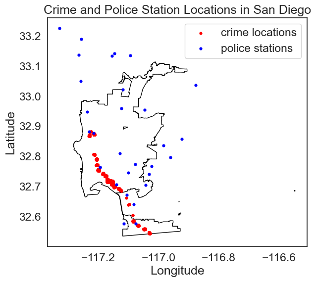

```python
crime_locations = [Point(xy) for xy in zip(crimes_report['longitude'], crimes_report['latitude'])]
police_stations = [Point(xy) for xy in zip(sd_police_stations['longitude'], sd_police_stations['latitude'])]


gpd_crime = gpd.GeoDataFrame(crimes_report, geometry=crime_locations)
gpd_police = gpd.GeoDataFrame(sd_police_stations, geometry=police_stations)

sd_boundaries_fp = 'san_diego_boundary_datasd.geojson'
sd_county = gpd.read_file(sd_boundaries_fp)

ax = sd_county.plot(figsize=(10, 6), color='white', edgecolor='black')
gpd_crime.plot(ax=ax, marker='o', color='red', markersize=12, label='crime locations')
gpd_police.plot(ax=ax,marker='o', color='blue', markersize=12, label='police stations')

plt.xlabel("Longitude")
plt.ylabel("Latitude")
plt.title("Crime and Police Station Locations in San Diego")
plt.legend()
plt.show()
```

### Exploring Relationships Between Rates of Crime Activity at Each Trolley Stop

To uncover potential correlations between property values and police station proximity to crime rates, it is important to first understand the distribution of crime rates at each trolley stop. The horizontal bar chart below illustrates this distribution. For each trolley stop on the Blue Line, the chart shows the corresponding number of criminal incidents.

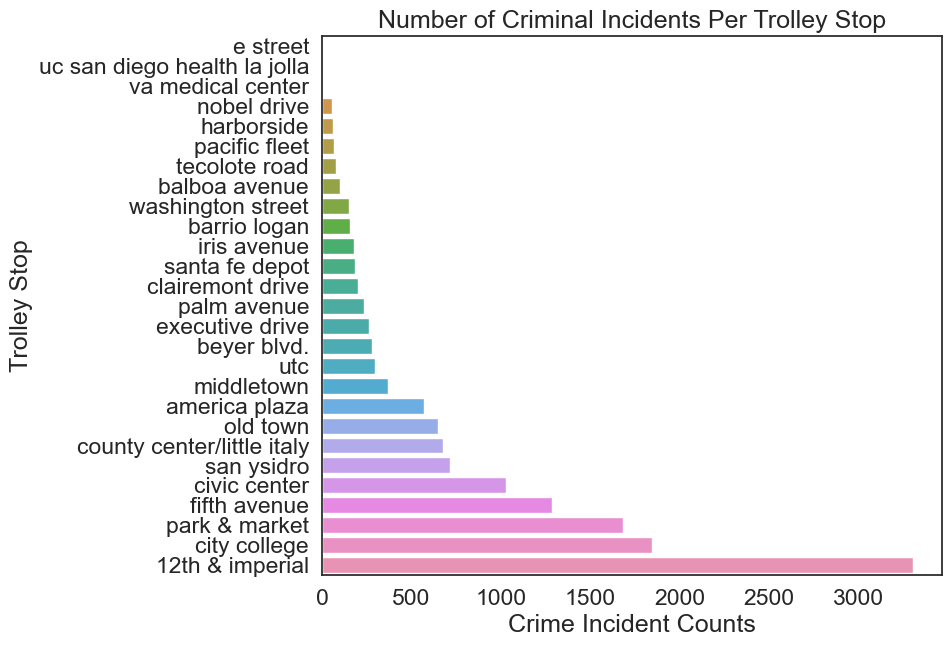

```python
plt.figure(figsize=(8, 7))

crimes_per_stop = ((crimes_and_homes.groupby(['closest_stop', 'la_jolla'])['min_distance'].count()
                    .sort_values())
                    .reset_index()
                    .rename(columns={'min_distance': 'crime_counts'}))
sns.barplot(x=crimes_per_stop['crime_counts'], y=crimes_per_stop['closest_stop'])
plt.title('Number of Criminal Incidents Per Trolley Stop')
plt.xlabel('Crime Incident Counts')
plt.ylabel('Trolley Stop')
```

The horizontal bar plot above is useful for visualizing the distribution of crime activity at each individual trolley stop. However, because our analysis specifically focuses on the disparities between trolley stops within and outside of La Jolla, we additionally highlighted these distinctions in the bar chart below. Grouping trolley stops into the categories 'True' and 'False' for whether they fall within La Jolla, the bar chart belows depicts the average number of criminal incidents within each category. The visualization reveals a significant difference in average criminal activity.

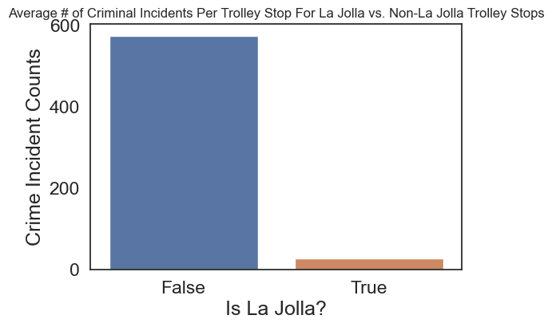

```python
# count the number of La Jolla and non-La Jolla stops and store in a series
n_lj_stops = crimes_and_homes[crimes_and_homes['la_jolla'] == True]['closest_stop'].nunique()
n_non_lj_stops = crimes_and_homes[crimes_and_homes['la_jolla'] == False]['closest_stop'].nunique()
num_stops = pd.Series([n_lj_stops, n_non_lj_stops], index=[True, False])

# the plot below compares the average number of crime rates for La Jolla vs. non-Jolla stops on the Blue Line
avg_crimes = crimes_and_homes.groupby('la_jolla')['min_distance'].count() / num_stops
plt.figure(figsize=(6, 4))
sns.barplot(x=avg_crimes.index, y=avg_crimes.values)
plt.title('Average # of Criminal Incidents Per Trolley Stop For La Jolla vs. Non-La Jolla Trolley Stops',  fontsize=12)
plt.xlabel('Is La Jolla?')
plt.ylabel('Crime Incident Counts')
```

After understanding the distribution of criminal activity for both individual trolley stops and La Jolla vs. non-La Jolla stops, we want to explore relationships between variables that may correlate with these patterns. Specifically for our analysis, we wish to examine how factors such as property values and proximity to police stations correlate with the observed crime rates.

For property value, we used our Zillow dataset to determine the average home values for neighborhoods surrounding trolley stops both within and outside of La Jolla. The relationship between the number of crimes and the average home for each trolley stop is depicted in the scatterplot below. To differentiate between La Jolla and non-La Jolla stops, the stops are marked with different colors indicating their respective categories. From this plot, we can observe a potential relationship between property value and crime, although the relationship does not appear to be significant.

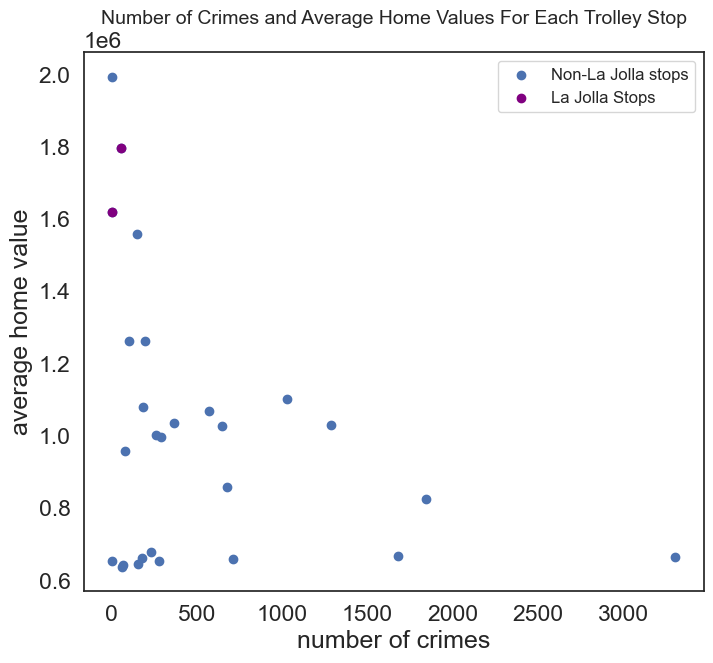

```python
# find the average home value surrounding each trolley stop
avg_home_value_per_stop = crimes_and_homes.groupby('closest_stop')['avg_home_value'].mean()
avg_home_and_crimes = pd.DataFrame({'avg_home_value_per_stop': avg_home_value_per_stop,
                   'crimes_per_stop': crimes_per_stop.set_index('closest_stop')['crime_counts']})

la_jolla_home_and_crimes = avg_home_and_crimes.loc[['uc san diego health la jolla', 'nobel drive'], :]

# the scatterplot below shows the relationship between the # of crimes and the average home values for each trolley stop on the Blue Line
# La Jolla trolley stops are highlighted red
plt.figure(figsize=(8, 7))
plt.scatter(avg_home_and_crimes['crimes_per_stop'], avg_home_and_crimes['avg_home_value_per_stop'], label='Non-La Jolla stops')
plt.scatter(la_jolla_home_and_crimes['crimes_per_stop'], la_jolla_home_and_crimes['avg_home_value_per_stop'], color='purple', label='La Jolla Stops')
plt.xlabel('number of crimes')
plt.ylabel('average home value')
plt.title('Number of Crimes and Average Home Values For Each Trolley Stop', fontsize=14)
plt.legend(fontsize=12)

plt.show()
```

Similarly, we generated a scatter plot to illustrate the relationship between police station proximity and crime activity. The scatter plot is shown as a function of proximity to closest police station in kilometers and number of crimes. La Jolla and non-Jolla stops are differentiated for our analysis and there does not appear to be an intuitive relationship depicted by the plot.

```python
# this function is used to find the distance of the closest police station to each trolley stop

police_station_coordinates = list(zip(sd_police_stations['latitude'], sd_police_stations['longitude']))
police_station_coordinates

def min_distance_to_police(lat1, lon1):

      R = 6371.0  # radius of the Earth in kilometers
      stations = police_station_coordinates
      distances = []

      # convert latitude and longitude from degrees to radians
      for station in police_station_coordinates:
            lat2, lon2 = station[0], station[1]
            lat_radians1, lon_radians1, lat_radians2, lon_radians2 = map(radians, [lat1, lon1, lat2, lon2])

            # Haversine formula
            dlat = lat_radians2 - lat_radians1
            dlon = lon_radians2 - lon_radians1
            a = sin(dlat / 2)**2 + cos(lat_radians1) * cos(lat_radians2) * sin(dlon / 2)**2
            c = 2 * atan2(sqrt(a), sqrt(1 - a))
            distances.append(R * c) # distance in kilometers

      min_distance = min(distances)

      return min_distance
```

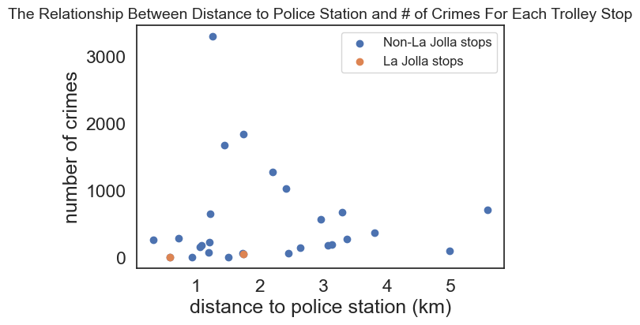

```python
# a series of each trolley stop on the Blue Line and the distance to the closest police station in kilometers
dist_to_police = pd.Series({stop: min_distance_to_police(location[0], location[1]) for stop, location in BL_STOP_LOCATIONS.items()})

# a dataframe containing the trolley stop, the number of crimes recorded, and closest distance to a police station
police_and_crime = (pd.DataFrame(dist_to_police).merge(pd.DataFrame(crimes_per_stop.set_index('closest_stop')['crime_counts']), left_index=True, right_index=True, how='right'))
police_and_crime.columns = ['min_dist_to_police', 'num_crimes']
police_and_crime['la_jolla'] = police_and_crime.index.to_series().apply(lambda x: x in LA_JOLLA_STOPS)

plt.figure(figsize=(6, 4))
plt.scatter(police_and_crime['min_dist_to_police'], police_and_crime['num_crimes'], label='Non-La Jolla stops')
plt.scatter(police_and_crime[police_and_crime['la_jolla'] == True]['min_dist_to_police'],
            police_and_crime[police_and_crime['la_jolla'] == True]['num_crimes'], label='La Jolla stops')
plt.xlabel('distance to police station (km)')
plt.ylabel('number of crimes')
plt.title('The Relationship Between Distance to Police Station and # of Crimes For Each Trolley Stop', fontsize=14)
plt.legend(fontsize=12)
```

### Exploring Changes over Time

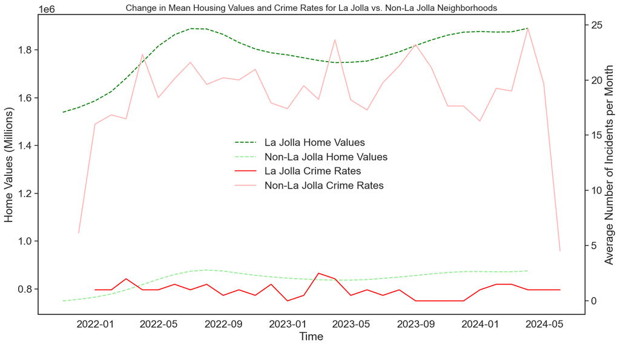

```python
# home values over time for La Jolla and non-La Jolla stops
neighborhood_home_values = (crimes_and_homes[crimes_and_homes.columns[np.r_[13, 21:crimes_and_homes.shape[1]-1]]].groupby('la_jolla').mean()).T
neighborhood_home_values.index = neighborhood_home_values.index = pd.to_datetime(neighborhood_home_values.index)

# crime rates over time for La Jolla and non-La Jolla stops
lj_crimes_and_home = crimes_and_homes[crimes_and_homes['closest_stop'].isin(LA_JOLLA_STOPS)]
non_lj_crimes_and_home = crimes_and_homes[~crimes_and_homes['closest_stop'].isin(LA_JOLLA_STOPS)]
lj_monthly_crimes = lj_crimes_and_home.resample('M', on='occurred_on').count()
non_lj_monthly_crimes = non_lj_crimes_and_home.resample('M', on='occurred_on').count()
avg_non_lj_monthly_crimes = non_lj_monthly_crimes['city'] / n_non_lj_stops
avg_lj_monthly_crimes = lj_monthly_crimes['city'] / n_lj_stops

fig, ax1 = plt.subplots(figsize=(14, 8))  # figsize for declutter

# Plot home values over time for both categories (dashed)
sns.lineplot(x=neighborhood_home_values.index, y=neighborhood_home_values[True], ax=ax1,
             color='green', linestyle='--', label='La Jolla Home Values')  # Exclude from legend
sns.lineplot(x=neighborhood_home_values.index, y=neighborhood_home_values[False], ax=ax1,
             color='#90EE90', linestyle='--', label='Non-La Jolla Home Values')  # Exclude from legend

ax1.set_ylabel('Home Values (Millions)')
ax1.set_xlabel('Time')

# Plot crime rates over time for both categories (regular)
ax2 = ax1.twinx()  # Create a second y-axis for the crime rates
crime_line_lj = sns.lineplot(x=avg_lj_monthly_crimes.index, y=avg_lj_monthly_crimes.values, ax=ax2,
                             color='red', label='La Jolla Crime Rates')
crime_line_nonlj = sns.lineplot(x=avg_non_lj_monthly_crimes.index, y=avg_non_lj_monthly_crimes.values, ax=ax2,
                                color='#FFB3B3', label='Non-La Jolla Crime Rates')

ax2.set_ylabel('Average Number of Incidents per Month')

# 4 line legend in the center
lines_1, labels_1 = ax1.get_legend_handles_labels()
lines_2, labels_2 = ax2.get_legend_handles_labels()
ax2.legend(lines_1 + lines_2, labels_1 + labels_2, loc='best', frameon=False)

ax1.get_legend().remove() # hide

plt.title('Change in Mean Housing Values and Crime Rates for La Jolla vs. Non-La Jolla Neighborhoods', fontsize=14)
plt.tight_layout()
plt.show()
```

Comparing between La Jolla versus non-La Jolla region **over time**, we see the following insight. For the La Jolla region, higher average home values is paired with lower crime rates. Meanwhile, lower average home values is paired with higher crime rates.

### Understanding Significance: Permutation Test

While the figures above intuitively depict a significant difference in the frequency of criminal incidents at La Jolla and non-Jolla trolley stops, conducting a statistical test would provide a rigorous method to determine whether this observed difference is statistically significant. Here, we can use a permutation test to examine whether the observed difference can be explained by random chance.

Our hypothesis is the same as previously defined:  
**Null hypothesis**: There is no significant difference in the rates of criminal incidents between La Jolla trolley stops on the Blue Line and non-La Jolla trolley stops within San Diego.

**Alternate hypothesis**: La Jolla trolley stops on the Blue Line experience lower rates of criminal incidents compared to non-La Jolla trolley stops within San Diego.

The significance level is **5**%.

The test statistic for this permutation test is the difference in average crime incidents per stop for La Jolla and non-La Jolla trolley stops. If La Jolla and non-La Jolla trolley stops were to come from the same distribution, it would mean that there is no actual difference in the rates of criminal incidents between them. Therefore, randomly shuffling the labels in the `la_jolla` column would result in test statistics centered around zero. However, if there is a significant difference in the rates of criminal activity, a permutation test would yield a statistically significant p-value, confirming the presence of a true difference between the two locations.

```python
# calculate the observed statistic:
# avg crime per stop in La Jolla - # avg crime per stop outside La Jolla
avg_crimes = crimes_per_stop.groupby('la_jolla')['crime_counts'].mean()
obs_stat = avg_crimes[True] - avg_crimes[False]
print("If the observed stat is negative, then that means the average crime rates in La Jolla trolley stop is smaller than Non-La Jolla Trolley stops. obs_stat:", obs_stat)

# define a function to compute the test statistic
def diff_of_avg_crime(shuffled_df):
    shuffled_means = shuffled_df.groupby('la_jolla')['crime_counts'].mean()
    return shuffled_means[True] - shuffled_means[False]


# define a function to perform permutation test
def simulate_stat(df):
    shuffled = df.copy()
    shuffled['la_jolla'] = np.random.permutation(shuffled['la_jolla'])
    return diff_of_avg_crime(shuffled)



# simulate 1000 samples
test_stats = [simulate_stat(crimes_per_stop) for i in range(1000)]
p_value = (pd.Series(test_stats) <= obs_stat).mean()
p_value
```

```
If the observed stat is negative, then that means the average crime rates in La Jolla trolley stop is smaller than Non-La Jolla Trolley stops. obs_stat: -546.38
```

```
0.015
```

After conducting the permutation test, we obtained a resulting p-value that falls below our defined significance level of 0.05, indicating that there is a statistically significant difference in the rates of criminal incidents between La Jolla and non-La Jolla trolley stops on the Blue Line. Therefore, the difference in criminal incidents rates cannot be attributed to random chance alone. While our anaylsis observed correlation with property values and crime rates surrounding trolley stops, further exploration must be done to determine if the relationship is casual. Additionally, this leaves room for future spatial-temporal analysis to discover other potential contributing factors.

### Exploration of the Different Types of Crime and their Frequencies

For additional curiousities, we wanted to examine what types of crimes are the most common at each trolley stop. First, we generated a bar plot to display crime types and their frequency as the top 1 crime for each trolley stop. This will give us some insight into the dominant safety concerns and patterns of criminal activity associated with trolley stops.

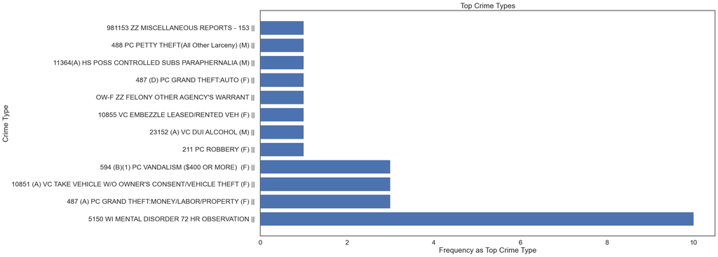

```python
def find_top_crime(ser):
    return ser['code_section'].value_counts().index[0]

top_crimes_per_stop = (crimes_and_homes.groupby('closest_stop').apply(find_top_crime)
                      .reset_index()
                      .rename(columns={0: 'crime_type'}))

total_top_crimes = top_crimes_per_stop['crime_type'].value_counts()

plt.figure(figsize=(20, 10))
plt.barh(total_top_crimes.index, total_top_crimes.values)
plt.xlabel('Frequency as Top Crime Type')
plt.ylabel('Crime Type')
plt.title('Top Crime Types')
```

From this plot, we can see that code section: 5150 WI Mental Disorder is by far the most commonly observed crime type, with it being the top crime type at ten different trolley stops. Additionally, we can see that other prevalent crime types at trolley stops include 487 PC Grand Theft, 10851 VC Vehicle Theft, and 594 PC Vandalism.

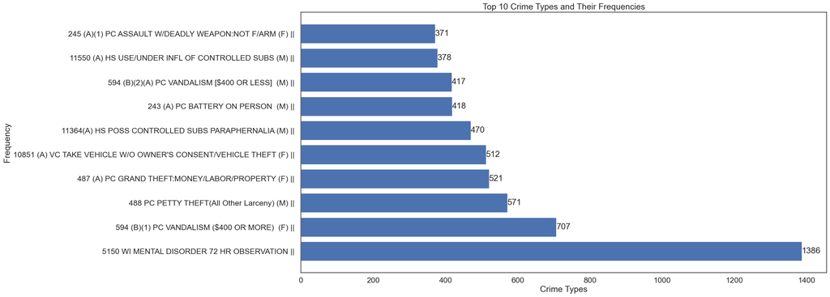

```python
code_section_counts = crimes_and_homes['code_section'].value_counts()

top_10_code_sections = code_section_counts.sort_values(ascending=False).head(10)
top_10_code_sections


plt.figure(figsize=(20, 10))
bars = plt.barh(top_10_code_sections.index, top_10_code_sections.values)

plt.xlabel('Crime Types')
plt.ylabel('Frequency')
plt.title('Top 10 Crime Types and Their Frequencies')


for bar in bars:
    plt.text(bar.get_width(), bar.get_y() + bar.get_height() / 2,
             f'{bar.get_width():.0f}', va='center', ha='left')

plt.show()
```

To get an understanding of the frequency of these crime types, we also plotted another bar chart to visualize the actual values of occurrence. With this graph, we can once again see that mental health related crimes dominate over others at the trolleys stops, potentially suggesting a need for support services in these areas. As for other crime types, the distribution appears relatively consistent.

### Geospatial Explorations

We obtained the dataset of neighborhoods of San Diego from [David Blackman](https://github.com/blackmad/neighborhoods/blob/master/san-diego.geojson).

Seeing that neighborhoods and crime rates are correlated, we can explore the geospatial relationship between property value and police station proximity with respect to Blue Line trolley stops. The limitation of this data set is that it does not cover Chula Vista.

1. Here is a visualization of the intricacies of neighborhoods.

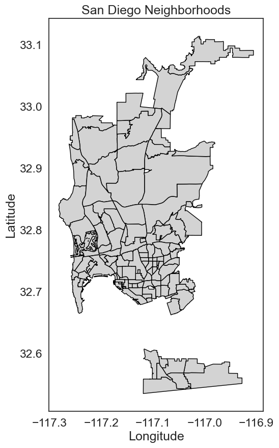

```python
gdf = gpd.read_file('san-diego.geojson')

fig, ax = plt.subplots(figsize=(10, 10))
gdf.plot(ax=ax, color='lightgrey', edgecolor='black')

plt.title('San Diego Neighborhoods')
plt.xlabel('Longitude')
plt.ylabel('Latitude')
plt.show()
```

```python
gdf['name'] = gdf['name'].str.upper()
gdf = gdf.merge(crimes_and_homes, left_on="name", right_on="neighborhood", how="left")
gdf = gdf.dropna(subset=["nibrs_uniq"])

gdf.head(5)
```

|  | name | cartodb_id | created_at | updated_at | geometry | nibrs_uniq | occurred_on | day_of_week | code_section | neighborhood | ... | 2023-07-31 | 2023-08-31 | 2023-09-30 | 2023-10-31 | 2023-11-30 | 2023-12-31 | 2024-01-31 | 2024-02-29 | 2024-03-31 | avg_home_value |
| --- | --- | --- | --- | --- | --- | --- | --- | --- | --- | --- | --- | --- | --- | --- | --- | --- | --- | --- | --- | --- | --- |
| 1 | EGGER HIGHLANDS | 2 | 2013-02-16 03:11:02.653000+00:00 | 2013-02-16 03:11:19.974000+00:00 | MULTIPOLYGON (((-117.10971 32.60428, -117.1082... | 3181862_90Z | 2024-02-14 17:30:46 | 4.0 | BW-F ZZ FELONY BENCH WARRANT (OUR AGENCY) \|\| O... | EGGER HIGHLANDS | ... | 7.298323e+05 | 7.407001e+05 | 7.505508e+05 | 7.584084e+05 | 7.638536e+05 | 7.677207e+05 | 7.713064e+05 | 7.763904e+05 | 7.833352e+05 | 7.193012e+05 |
| 2 | OLD TOWN | 3 | 2013-02-16 03:11:02.653000+00:00 | 2013-02-16 03:11:19.974000+00:00 | MULTIPOLYGON (((-117.19062 32.75900, -117.1898... | 3025745_90Z | 2022-09-24 20:30:14 | 7.0 | BW-F ZZ FELONY BENCH WARRANT (OUR AGENCY) \|\| | OLD TOWN | ... | 1.026016e+06 | 1.036811e+06 | 1.047452e+06 | 1.054330e+06 | 1.055928e+06 | 1.053070e+06 | 1.050726e+06 | 1.052207e+06 | 1.059987e+06 | 1.031713e+06 |
| 3 | OLD TOWN | 3 | 2013-02-16 03:11:02.653000+00:00 | 2013-02-16 03:11:19.974000+00:00 | MULTIPOLYGON (((-117.19062 32.75900, -117.1898... | 3041619_90Z | 2022-11-14 23:29:00 | 2.0 | 5150 WI MENTAL DISORDER 72 HR OBSERVATION \|\| | OLD TOWN | ... | 1.026016e+06 | 1.036811e+06 | 1.047452e+06 | 1.054330e+06 | 1.055928e+06 | 1.053070e+06 | 1.050726e+06 | 1.052207e+06 | 1.059987e+06 | 1.031713e+06 |
| 4 | OLD TOWN | 3 | 2013-02-16 03:11:02.653000+00:00 | 2013-02-16 03:11:19.974000+00:00 | MULTIPOLYGON (((-117.19062 32.75900, -117.1898... | 2998226_23H | 2022-06-25 04:00:00 | 7.0 | 487 (A) PC GRAND THEFT:MONEY/LABOR/PROPERTY (F... | OLD TOWN | ... | 1.026016e+06 | 1.036811e+06 | 1.047452e+06 | 1.054330e+06 | 1.055928e+06 | 1.053070e+06 | 1.050726e+06 | 1.052207e+06 | 1.059987e+06 | 1.031713e+06 |
| 5 | OLD TOWN | 3 | 2013-02-16 03:11:02.653000+00:00 | 2013-02-16 03:11:19.974000+00:00 | MULTIPOLYGON (((-117.19062 32.75900, -117.1898... | 3131896_290 | 2023-06-21 22:55:00 | 4.0 | 594 (B)(1) PC VANDALISM ($400 OR MORE) (F) \|\| | OLD TOWN | ... | 1.026016e+06 | 1.036811e+06 | 1.047452e+06 | 1.054330e+06 | 1.055928e+06 | 1.053070e+06 | 1.050726e+06 | 1.052207e+06 | 1.059987e+06 | 1.031713e+06 |

5 rows × 57 columns

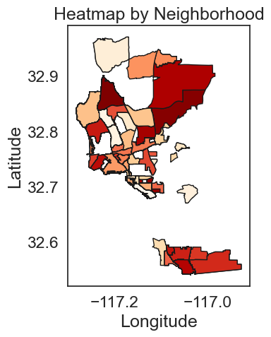

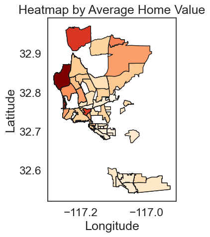

```python
ax = gdf.plot(column="neighborhood", cmap="OrRd", edgecolor="k")
ax.set_xlabel('Longitude')
ax.set_ylabel('Latitude')
ax.set_title('Heatmap by Neighborhood')
plt.show()



ax = gdf.plot(column="avg_home_value", cmap="OrRd", edgecolor="k")
ax.set_xlabel('Longitude')
ax.set_ylabel('Latitude')
ax.set_title('Heatmap by Average Home Value')
plt.show()
```

# Ethics & Privacy

In obtaining the relevant data for our analysis, there are several important considerations regarding ethics and privacy. In general, most of our datasets—San Diego Metro Transit records, property values, education rankings—are publicly available records and we do not anticipate any privacy issues. However, biases may arise in other aspects of our data, including our population of interest: people who utilize the San Diego trolley. Several factors influence the frequency of trolley usage, from socioeconomic to demographic to geographic. These variances shape individual interactions with the trolley systems and may also impact the behaviors and experiences we observe, leading to bias. We aim to be transparent about this in our analysis. Another dataset that may raise a privacy concern is the San Diego NIBS Police Report Data. This dataset contains specific information about crime offenses and addresses that could be considered sensitive. We plan to mitigate this issue by properly handling the data so that privacy is prioritized.

One main ethical concern for the findings of our project is the potential stigmatization of areas that may be revealed to experience higher rates of criminal activity. Because our project concerns communities and neighborhoods, we understand that results must be articulated carefully and responsibly. We will also maintain transparency of the analysis techniques and methodologies used to construct our results.

# Discussion and Conclusion

While carrying out our analysis, we also performed exploratory data analysis to draw connections between crime rates and other characteristics. After getting a general overview of the location of crime incidents and police stations, we proceeded to analyze the relationships between crime rates at each stop, crime rates and home value property values over time, different crimes and their frequencies, and geospatial explorations between crime incidents and property values.

The findings from our research reveal disparities in crime rates, with Non-La Jolla stops experiencing considerably higher crime compared to La Jolla stops. This study has potential implications for public safety, resource allocation, and community trust in public transportation. In addition to the disparity in crime rates, we found that the most prominent crimes are related to mental health issues among individuals using the public transportation system. This finding underscores the critical need for targeted interventions and enhanced mental health support to address this concern.

These insights call for change. Policymakers and urban planners can use this data to push for investments in safety measures, especially in Non-La Jolla stops, by improving infrastructure, surveillance, and emergency response capabilities to help reduce crime rates and foster more secure transit. By making changes and raising awareness, this could reduce stigma and promote vigilance for the city’s public transport which will ultimately contribute to a more equitable and secure transit system.

# Team Contributions

William Heng scouted for datasets, finding publicly available police records which were integral. He worked on enriching the datasets by adding geographical coordinates as well as graphical and descriptive analysis for crime patterns, for types of crimes, and mapping police stations. He also worked on the Abstract, Team video, Team Expectations and refined the Background sections.

Vuong Bui suggested the initial research question which was refined through team discussion and did research into prior related studies to develop the Background as well as Ethics and Concerns sections to contribute to our study’s credibility, reliability, and societal impacts. He also worked on describing datasets, creating graphical visualizations, along with creating and organizing the presentation slide-deck used for the team video.

Emily Chen initiated team meetings, recorded what to do for each member and as a group, collected the home value dataset with Sharon as well as the San Diego police station dataset. She also wrote background information about the dataset with Sharon and performed geospatial analysis on property value and crime incidents. Additionally, she helped merge everyone’s code in GitHub.

Sharon Ni performed the majority of the data cleaning and data wrangling to ensure the accuracy of datasets for analysis. She also carried out exploratory data analysis and generated graphs to illustrate trends in the dataset. She also conducted the permutation test and completed the Ethics and Privacy section of the write-up.

Rina Pecherskaya refined various aspects of our project, providing feedback to enhance its quality and coherence. She conducted a side analysis on demographic variables and crime rates, which informed our research phase, and played a crucial role in decluttering final plots and editing our presentation slides based on grader feedback, ensuring clear and effective communication.